# Joining data with `dplyr`

Felix Lennert

knit on 2020-06-20

# Introduction

The last session showed you three things: how you get datasets into R, a couple of ways to create tibbles, and an introduction to tidy data and how to make datasets tidy using the `tidyr` package. As you may recall from the last session, it was not able to solve the last two problems with only the tools `tidyr` offers. In particular, the problems were:

- Multiple types of observational units are stored in the same table.
- A single observational unit is stored in multiple tables.

Both problems need some different kind of tools: joins. Joins can be used to merge tibbles together. This tutorial, again, builds heavy on the R for Data Science book (Wickham and Grolemund 2016)

# Multiple types of units are in the same table

Let’s look at the following dataset. It contains the billboard charts in 2000 and was obtained from the [`tidyr` GitHub repo](https://github.com/tidyverse/tidyr/blob/master/data/billboard.rda). The example below is taken from the `tidyr` vignette which can be loaded using `vignette("tidy-data", package = "tidyr")`.

```r
library(tidyverse)
library(lubridate)
load("data/billboard.rda")
```

```r
glimpse(billboard)
```

```
## Rows: 317
## Columns: 79
## $ artist       <chr> "2 Pac", "2Ge+her", "3 Doors Down", "3 Doors Down", "504…
## $ track        <chr> "Baby Don't Cry (Keep...", "The Hardest Part Of ...", "K…
## $ date.entered <date> 2000-02-26, 2000-09-02, 2000-04-08, 2000-10-21, 2000-04…
## $ wk1          <dbl> 87, 91, 81, 76, 57, 51, 97, 84, 59, 76, 84, 57, 50, 71, …
## $ wk2          <dbl> 82, 87, 70, 76, 34, 39, 97, 62, 53, 76, 84, 47, 39, 51, …
## $ wk3          <dbl> 72, 92, 68, 72, 25, 34, 96, 51, 38, 74, 75, 45, 30, 28, …
## $ wk4          <dbl> 77, NA, 67, 69, 17, 26, 95, 41, 28, 69, 73, 29, 28, 18, …
## $ wk5          <dbl> 87, NA, 66, 67, 17, 26, 100, 38, 21, 68, 73, 23, 21, 13,…
## $ wk6          <dbl> 94, NA, 57, 65, 31, 19, NA, 35, 18, 67, 69, 18, 19, 13, …
## $ wk7          <dbl> 99, NA, 54, 55, 36, 2, NA, 35, 16, 61, 68, 11, 20, 11, 3…
## $ wk8          <dbl> NA, NA, 53, 59, 49, 2, NA, 38, 14, 58, 65, 9, 17, 1, 29,…
## $ wk9          <dbl> NA, NA, 51, 62, 53, 3, NA, 38, 12, 57, 73, 9, 17, 1, 27,…
## $ wk10         <dbl> NA, NA, 51, 61, 57, 6, NA, 36, 10, 59, 83, 11, 17, 2, 30…
```

[output cut: 66 more lines]

Here, you can immediately see the problem: it contains two types of observations: songs and ranks. Hence, the dataset needs to be split up. However, there should be a pointer from the rank dataset to the song dataset. First, I add an ID column to `song_tbl`. Then, I can add it to `rank_tbl` and drop the unneccessary columns which contain the name of the artist and the track.

```r
song_tbl <- billboard %>%
  distinct(artist, track) %>%
  mutate(song_id = row_number())
```

```r
rank_tbl <- billboard %>%
  pivot_longer(cols = starts_with("wk"),
               names_to = "week",
               names_prefix = "wk",
               values_to = "rank") %>%
  mutate(week = as.numeric(week),
         date = date.entered + week * 7) %>%
  drop_na() %>%
  left_join(song_tbl, by = c("artist", "track")) %>%
  select(song_id, date, week, rank)
```

# One unit is in multiple tables

For this example, I have split up a dataset from the `socviz` package containing data on the 2016 elections in the U.S. according to census region and stored them in a folder. I can scrape the file names in the folder and read it into a list in an automated manner. You will learn this when we touch upon iteration.

```r
library(fs)
file_list <- dir_ls(path = "data/socviz_us") %>%
  map(read_csv,
      col_types = cols(
        id = col_double(),
        name = col_character(),
        state = col_character(),
        census_region = col_character(),
        pop_dens = col_character(),
        pop_dens4 = col_character(),
        pop_dens6 = col_character(),
        pct_black = col_character(),
        pop = col_double(),
        female = col_double(),
        white = col_double(),
        black = col_double(),
        travel_time = col_double(),
        land_area = col_double(),
        hh_income = col_double(),
        su_gun4 = col_character(),
        su_gun6 = col_character(),
        fips = col_double(),
        votes_dem_2016 = col_double(),
        votes_gop_2016 = col_double(),
        total_votes_2016 = col_double(),
        per_dem_2016 = col_double(),
        per_gop_2016 = col_double(),
        diff_2016 = col_double(),
        per_dem_2012 = col_double(),
        per_gop_2012 = col_double(),
        diff_2012 = col_double(),
        winner = col_character(),
        partywinner16 = col_character(),
        winner12 = col_character(),
        partywinner12 = col_character(),
        flipped = col_character()
))
```

The list now consists of four tibbles which need to be bound together. You can achieve this using `bind_rows()`. Its counterpart is `bind_cols()` which binds columns together. It matches rows by position.

```r
election_data <- file_list %>% bind_rows()
election_data
```

```
## # A tibble: 3,141 x 32
##       id name  state census_region pop_dens pop_dens4 pop_dens6 pct_black    pop
##    <dbl> <chr> <chr> <chr>         <chr>    <chr>     <chr>     <chr>      <dbl>
##  1 17001 Adam… IL    Midwest       [   50,… [ 45,  1… [ 45,   … [ 2.0, 5…  66988
##  2 17003 Alex… IL    Midwest       [   10,… [ 17,   … [ 25,   … [25.0,50…   7492
##  3 17005 Bond… IL    Midwest       [   10,… [ 45,  1… [ 45,   … [ 5.0,10…  17269
##  4 17007 Boon… IL    Midwest       [  100,… [118,716… [ 82,  2… [ 2.0, 5…  53869
##  5 17009 Brow… IL    Midwest       [   10,… [ 17,   … [  9,   … [15.0,25…   6832
##  6 17011 Bure… IL    Midwest       [   10,… [ 17,   … [ 25,   … [ 0.0, 2…  33840
##  7 17013 Calh… IL    Midwest       [   10,… [ 17,   … [  9,   … [ 0.0, 2…   4956
##  8 17015 Carr… IL    Midwest       [   10,… [ 17,   … [ 25,   … [ 0.0, 2…  14715
##  9 17017 Cass… IL    Midwest       [   10,… [ 17,   … [ 25,   … [ 2.0, 5…  13156
## 10 17019 Cham… IL    Midwest       [  100,… [118,716… [ 82,  2… [10.0,15… 207133
## # … with 3,131 more rows, and 23 more variables: female <dbl>, white <dbl>,
## #   black <dbl>, travel_time <dbl>, land_area <dbl>, hh_income <dbl>,
## #   su_gun4 <chr>, su_gun6 <chr>, fips <dbl>, votes_dem_2016 <dbl>,
## #   votes_gop_2016 <dbl>, total_votes_2016 <dbl>, per_dem_2016 <dbl>,
## #   per_gop_2016 <dbl>, diff_2016 <dbl>, per_dem_2012 <dbl>,
## #   per_gop_2012 <dbl>, diff_2012 <dbl>, winner <chr>, partywinner16 <chr>,
## #   winner12 <chr>, partywinner12 <chr>, flipped <chr>
```

Now, the dataset is ready for cleaning and tidying. Feel free to do this is as a take-home exercise.

However, the topic of this script is different joins. The `dplyr` package offers six different joins: `left_join()`, `right_join()`, `inner_join()`, `full_join()`, `semi_join()`, and `anti_join()`. The former four are mutating joins, they add columns. The latter two can be used to filter rows in a dataset. Below is an overview from the `dplyr` cheatsheet:

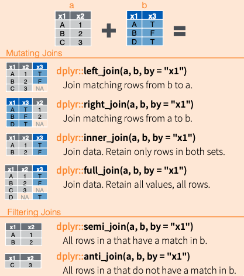

Overview of the different joins

In the following, I will illustrate this using the election data. I split up the dataset into three: data on the elections 2016 and 2012, and demographic data. The column they have in common is the county’s respective name.

```r
election_data16 <- election_data %>%
  select(name, state, votes_dem_2016:diff_2016, winner, partywinner16)

election_data12 <- election_data %>%
  select(name, state, per_dem_2012:partywinner12)

demographic_data <- election_data %>%
  select(name, state, pop:hh_income) %>%
  slice(1:2000)
```

## `left_join()` and `right_join()`

```r
election_data16 %>%
  left_join(demographic_data)
```

```
## # A tibble: 3,141 x 17
##    name  state votes_dem_2016 votes_gop_2016 total_votes_2016 per_dem_2016
##    <chr> <chr>          <dbl>          <dbl>            <dbl>        <dbl>
##  1 Adam… IL              7633          22732            31770        0.240
##  2 Alex… IL              1262           1496             2820        0.448
##  3 Bond… IL              2066           4884             7462        0.277
##  4 Boon… IL              8952          12261            22604        0.396
##  5 Brow… IL               475           1776             2336        0.203
##  6 Bure… IL              6010           9264            16303        0.369
##  7 Calh… IL               739           1719             2556        0.289
##  8 Carr… IL              2437           4428             7354        0.331
##  9 Cass… IL              1617           3216             5054        0.320
## 10 Cham… IL             49694          33235            89196        0.557
## # … with 3,131 more rows, and 11 more variables: per_gop_2016 <dbl>,
## #   diff_2016 <dbl>, winner <chr>, partywinner16 <chr>, pop <dbl>,
## #   female <dbl>, white <dbl>, black <dbl>, travel_time <dbl>, land_area <dbl>,
## #   hh_income <dbl>
```

If the column that both datasets have in common has the same name, there’s no need to provide it. If this is not the case, you need to provide it in a character vector:

```r
election_data16 %>%
  rename(county = name) %>%
  right_join(demographic_data, by = c("county" = "name"))
```

```
## # A tibble: 10,348 x 18
##    county state.x votes_dem_2016 votes_gop_2016 total_votes_2016 per_dem_2016
##    <chr>  <chr>            <dbl>          <dbl>            <dbl>        <dbl>
##  1 Adams… IL                7633          22732            31770        0.240
##  2 Adams… IL                7633          22732            31770        0.240
##  3 Adams… IL                7633          22732            31770        0.240
##  4 Adams… IL                7633          22732            31770        0.240
##  5 Adams… IL                7633          22732            31770        0.240
##  6 Adams… IL                7633          22732            31770        0.240
##  7 Adams… IL                7633          22732            31770        0.240
##  8 Adams… IL                7633          22732            31770        0.240
##  9 Adams… IL                7633          22732            31770        0.240
## 10 Alexa… IL                1262           1496             2820        0.448
## # … with 10,338 more rows, and 12 more variables: per_gop_2016 <dbl>,
## #   diff_2016 <dbl>, winner <chr>, partywinner16 <chr>, state.y <chr>,
## #   pop <dbl>, female <dbl>, white <dbl>, black <dbl>, travel_time <dbl>,
## #   land_area <dbl>, hh_income <dbl>
```

Here, the problem is that the same counties exist in different states. Therefore, all combinations are returned. Hence, I need to specify two arguments: the county’s name and state.

```r
election_data16 %>%
  rename(county = name) %>%
  right_join(demographic_data, by = c("county" = "name", "state"))
```

```
## # A tibble: 2,000 x 17
##    county state votes_dem_2016 votes_gop_2016 total_votes_2016 per_dem_2016
##    <chr>  <chr>          <dbl>          <dbl>            <dbl>        <dbl>
##  1 Adams… IL              7633          22732            31770        0.240
##  2 Alexa… IL              1262           1496             2820        0.448
##  3 Bond … IL              2066           4884             7462        0.277
##  4 Boone… IL              8952          12261            22604        0.396
##  5 Brown… IL               475           1776             2336        0.203
##  6 Burea… IL              6010           9264            16303        0.369
##  7 Calho… IL               739           1719             2556        0.289
##  8 Carro… IL              2437           4428             7354        0.331
##  9 Cass … IL              1617           3216             5054        0.320
## 10 Champ… IL             49694          33235            89196        0.557
## # … with 1,990 more rows, and 11 more variables: per_gop_2016 <dbl>,
## #   diff_2016 <dbl>, winner <chr>, partywinner16 <chr>, pop <dbl>,
## #   female <dbl>, white <dbl>, black <dbl>, travel_time <dbl>, land_area <dbl>,
## #   hh_income <dbl>
```

Left joins return all rows which are in `x`. If a column is in `x` but not in `y`, an `NA` will be included at this position. Right joins work vice versa.

## `inner_join()`

```r
election_data16 %>%
  inner_join(demographic_data)
```

```
## # A tibble: 2,000 x 17
##    name  state votes_dem_2016 votes_gop_2016 total_votes_2016 per_dem_2016
##    <chr> <chr>          <dbl>          <dbl>            <dbl>        <dbl>
##  1 Adam… IL              7633          22732            31770        0.240
##  2 Alex… IL              1262           1496             2820        0.448
##  3 Bond… IL              2066           4884             7462        0.277
##  4 Boon… IL              8952          12261            22604        0.396
##  5 Brow… IL               475           1776             2336        0.203
##  6 Bure… IL              6010           9264            16303        0.369
##  7 Calh… IL               739           1719             2556        0.289
##  8 Carr… IL              2437           4428             7354        0.331
##  9 Cass… IL              1617           3216             5054        0.320
## 10 Cham… IL             49694          33235            89196        0.557
## # … with 1,990 more rows, and 11 more variables: per_gop_2016 <dbl>,
## #   diff_2016 <dbl>, winner <chr>, partywinner16 <chr>, pop <dbl>,
## #   female <dbl>, white <dbl>, black <dbl>, travel_time <dbl>, land_area <dbl>,
## #   hh_income <dbl>
```

An `inner_join()` returns all rows which are in `x` and `y`.

## `full_join()`

```r
election_data16 %>%
  full_join(demographic_data)
```

```
## # A tibble: 3,141 x 17
##    name  state votes_dem_2016 votes_gop_2016 total_votes_2016 per_dem_2016
##    <chr> <chr>          <dbl>          <dbl>            <dbl>        <dbl>
##  1 Adam… IL              7633          22732            31770        0.240
##  2 Alex… IL              1262           1496             2820        0.448
##  3 Bond… IL              2066           4884             7462        0.277
##  4 Boon… IL              8952          12261            22604        0.396
##  5 Brow… IL               475           1776             2336        0.203
##  6 Bure… IL              6010           9264            16303        0.369
##  7 Calh… IL               739           1719             2556        0.289
##  8 Carr… IL              2437           4428             7354        0.331
##  9 Cass… IL              1617           3216             5054        0.320
## 10 Cham… IL             49694          33235            89196        0.557
## # … with 3,131 more rows, and 11 more variables: per_gop_2016 <dbl>,
## #   diff_2016 <dbl>, winner <chr>, partywinner16 <chr>, pop <dbl>,
## #   female <dbl>, white <dbl>, black <dbl>, travel_time <dbl>, land_area <dbl>,
## #   hh_income <dbl>
```

A `full_join()` returns rows and columns from both `x` and `y`.

## `semi_join()`

Filtering joins only keep the cases from `x`, no dataset is added.

```r
election_data16 %>%
  semi_join(demographic_data)
```

```
## # A tibble: 2,000 x 10
##    name  state votes_dem_2016 votes_gop_2016 total_votes_2016 per_dem_2016
##    <chr> <chr>          <dbl>          <dbl>            <dbl>        <dbl>
##  1 Adam… IL              7633          22732            31770        0.240
##  2 Alex… IL              1262           1496             2820        0.448
##  3 Bond… IL              2066           4884             7462        0.277
##  4 Boon… IL              8952          12261            22604        0.396
##  5 Brow… IL               475           1776             2336        0.203
##  6 Bure… IL              6010           9264            16303        0.369
##  7 Calh… IL               739           1719             2556        0.289
##  8 Carr… IL              2437           4428             7354        0.331
##  9 Cass… IL              1617           3216             5054        0.320
## 10 Cham… IL             49694          33235            89196        0.557
## # … with 1,990 more rows, and 4 more variables: per_gop_2016 <dbl>,
## #   diff_2016 <dbl>, winner <chr>, partywinner16 <chr>
```

## `anti_join()`

```r
election_data16 %>%
  anti_join(demographic_data)
```

```
## # A tibble: 1,141 x 10
##    name  state votes_dem_2016 votes_gop_2016 total_votes_2016 per_dem_2016
##    <chr> <chr>          <dbl>          <dbl>            <dbl>        <dbl>
##  1 Onsl… NC             17156          36342            55364        0.310
##  2 Oran… NC             59105          18373            79830        0.740
##  3 Paml… NC              2427           4225             6772        0.358
##  4 Pasq… NC              8455           8082            16964        0.498
##  5 Pend… NC              9086          17317            27072        0.336
##  6 Perq… NC              2291           4143             6595        0.347
##  7 Pers… NC              7772          11116            19303        0.403
##  8 Pitt… NC             40967          35191            78264        0.523
##  9 Polk… NC              3715           6738            10723        0.346
## 10 Rand… NC             13074          49156            63615        0.206
## # … with 1,131 more rows, and 4 more variables: per_gop_2016 <dbl>,
## #   diff_2016 <dbl>, winner <chr>, partywinner16 <chr>
```

`anti_join()` returns all rows from `x` with no matching columns in `y`.

# Further links

- Another introduction can be found [here](https://stat545.com/join-cheatsheet.html).
- The [chapter in R4DS](https://r4ds.had.co.nz/relational-data.html) has some nice diagrams.

# References

Wickham, Hadley and Garrett Grolemund. 2016. *R for Data Science: Import, Tidy, Transform, Visualize, and Model Data*. First edition. Sebastopol, CA: O’Reilly.